# Item selection

Erhebungsinstrument „Überzeugungen zum Verhältnis von Theorie und Praxis von Lehramtsstudierenden“

Jürgen Schneider

University of Tübingen

Ruben Kulcsar

University of Linz

2024-04-19

[Link to OSF-Project](https://osf.io/jh6rx/)  
Questionnaire realized with [formr](https://formr.org/)  
see the questionnaire [here](https://showcase.formr.org/)

# Data import & cleaning

**Import**

```r
library(tidyverse)
library(rio)
itemsel <- rio::import("https://raw.githubusercontent.com/j-5chneider/uzvvtp-las/master/data/pilot1.csv")
```

**Cleaning: delete empty rows/ rows of test run**  
data collection began at 28th Jan 2019: deleting all test runs before that date

```r
library(lubridate)

itemsel <- itemsel %>%
  filter(!is.na(ended)) %>%                   # delete empty cases
  mutate(ended = dmy_hm(ended)) %>%           # transform column into date format
  filter(ended > dmy("27-01-2019"))           # delete test runs before first data collection
```

# Sample description

and editing/deleting unreasonable values (e.g. out of range data)

## Semester

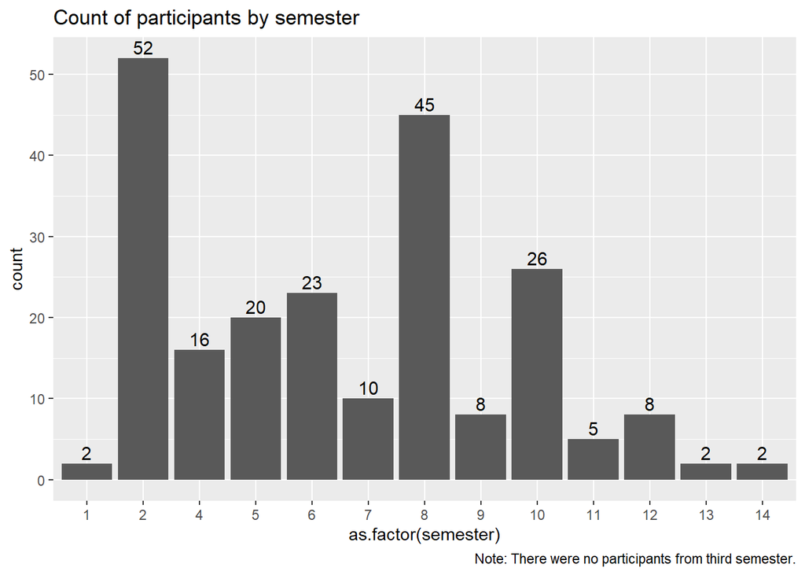

```r
# semester: no unreasonable values
ggplot(itemsel, aes(x = as.factor(semester))) +
  geom_bar() +
  labs(title = "Count of participants by semester",
       caption = "Note: There were no participants from third semester.") +
  geom_text(aes(label = ..count..), stat = "count", vjust = -0.3, size = 4)
```

## Standort

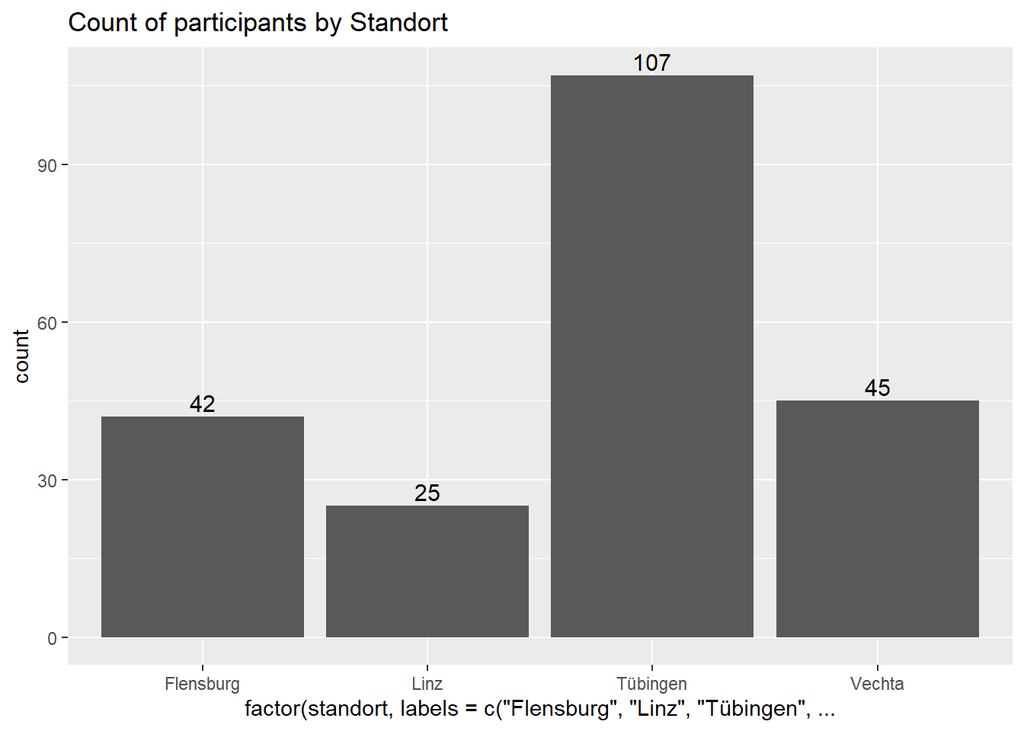

```r
# Standort: Two cases from Tübingen that checked Stuttgart
# However Stuttgart was not part of the sample and the time and date show the cases come from Tübingen
itemsel <- itemsel %>%
  mutate(standort = ifelse(standort == 4, 5, standort))

ggplot(itemsel, aes(x = factor(standort, labels = c("Flensburg", "Linz", "Tübingen", "Vechta")))) +
  geom_bar() +
  labs(title = "Count of participants by Standort") +
  geom_text(aes(label = ..count..), stat = "count", vjust = -0.3, size = 4)
```

## Subject

```r
library(knitr)
fach_freq <- data.frame(table(itemsel$fach))
names(fach_freq) <- c("Combination of Subjects", "Frequency")
kable(fach_freq, format = "html")
```

| Combination of Subjects | Frequency |
| --- | --- |
| 1, 2, 3, 5, 6, 7, 8, 9, 10, 11, 13, 14, 15, 16, 17, 18, 19, 20, 21, 22, 23, 24, 25, 26, 27, 28, 30, 31, 32, 33, 34, 35, 36, 37, 38, 39, 40, 41, 42, 43, 44, 45, 46, 47, 48, 49, 50, 51, 52 | 1 |
| 10, 11, 12, 15 | 1 |
| 11, 12, 37 | 1 |
| 11, 12, 44 | 1 |
| 11, 12, 46 | 1 |
| 11, 17 | 1 |
| 12 | 3 |
| 12, 13 | 9 |
| 12, 13, 17 | 1 |
| 12, 13, 18 | 3 |
| 12, 14, 18 | 1 |
| 12, 15 | 3 |
| 12, 17 | 1 |
| 12, 17, 25 | 1 |
| 12, 17, 39 | 1 |
| 12, 18 | 3 |
| 12, 25 | 1 |
| 12, 27 | 1 |
| 12, 31 | 1 |
| 12, 35 | 2 |
| 12, 37 | 4 |
| 12, 39 | 5 |
| 12, 44 | 3 |
| 13 | 1 |
| 13, 14, 18 | 1 |
| 13, 15 | 1 |
| 13, 16 | 1 |
| 13, 17 | 4 |
| 13, 17, 34 | 1 |
| 13, 17, 44 | 1 |

[output cut: 85 more lines]

one person seemed to have checked nearly all subjects -> deletion of that value

```r
itemsel <- itemsel %>%
  mutate(fach = ifelse(fach == "1, 2, 3, 5, 6, 7, 8, 9, 10, 11, 13, 14, 15, 16, 17, 18,
                       19, 20, 21, 22, 23, 24, 25, 26, 27, 28, 30, 31, 32, 33, 34, 35,
                       36, 37, 38, 39, 40, 41, 42, 43, 44, 45, 46, 47, 48, 49, 50, 51,
                       52", NA, fach))

rm(fach_freq)
```

# item descriptions

## item labels and codes

```r
# importing item labels and codes
items <- rio::import("https://raw.githubusercontent.com/j-5chneider/uzvvtp-las/master/data/items.csv")

library(kableExtra)

# table
items %>%
  kable() %>%
  column_spec(1:2, bold = T) %>%
  kableExtra::collapse_rows(columns = 1:2, valign = "middle") %>%
  row_spec(0, extra_css = "border-bottom: 2px solid #8F8F95") %>%
  row_spec(c(1:65), extra_css = "border-bottom: 1px solid #B9B8BC")
```

| Skala | Subskala | Code | Item Label |
| --- | --- | --- | --- |
| Transfer | Transfer | tfe_tfe_01 | Lehrer*innen leiten aus wissenschaftlichem Wissen direkt Handlungsentscheidungen für den Unterricht ab. |
|  |  | tfe_tfe_02 | Lehrer*innen wenden wissenschaftliches Wissen geradewegs im Schulalltag an. |
|  |  | tfe_tfe_03 | Wissenschaftliches Wissen wird durch Lehrer*innen unmittelbar auf praktisches Handeln in der Schule übertragen. |
|  |  | tfe_tfe_04 | Lehrer*innen verwenden wissenschaftliches Wissen unmittelbar für ihre schulische Praxis. |
|  |  | tfe_tfe_05 | Um in der schulischen Praxis handeln zu können, benötigen Lehrer*innen allein wissenschaftliches Wissen. |
|  |  | tfe_tfe_06 | Um guten Unterricht zu halten muss ein Lehrer nur auf wissenschaftliches Wissen zurückgreifen. |
|  |  | tfe_tfe_07 | Wer über Kenntnisse von wissenschaftlichem Wissen verfügt, kann auch professionell unterrichten. |
|  |  | tfe_tfe_08 | Schon allein die Kenntnis wissenschaftlichen Wissens ermöglicht es einer Person, Unterrichtssituationen professionell zu bewältigen. |
|  |  | tfe_tfe_09 | Um Herausforderungen der Schulpraxis zu begegnen, genügt es über viel wissenschaftliches Wissen zu verfügen. |
|  |  | tfe_tfe_10 | Wer über genug wissenschaftliches Wissen verfügt, kommt mit jedem Praxisproblem zurecht. |
|  |  | tfe_tfe_11 | Wer eine wissenschaftliche Theorie kennt, weiß auch automatisch, unter welchen Bedingungen sie in der Praxis angewandt werden kann. |
|  |  | tfe_tfe_12 | Wer eine wissenschaftliche Theorie wirklich verstanden hat, kann sie in der Praxis auch anwenden. |
|  | Didaktik | tfe_did_01 | Vorausgesetzt es wurde im Studium entsprechend vermittelt, leiten Lehrer*innen ihre Handlungsentscheidungen im Unterricht direkt aus wissenschaftlichem Wissen ab. |
|  |  | tfe_did_02 | Wenn ihnen das Wissen entsprechend vermittelt wurde, übertragen Lehrer*innen wissenschaftliches Wissen unmittelbar auf ihr praktisches Handeln. |
|  |  | tfe_did_03 | Sofern das wissenschaftliche Wissen den Lehrer*innen angemessen gelehrt wurde, können sie daraus direkt Handlungsentscheidungen für den Unterricht ableiten. |
|  |  | tfe_did_04 | Lehrer*innen verwenden wissenschaftliches Wissen unmittelbar für ihre schulische Praxis, gesetzt den Fall es wurde ihnen in geeigneter Form beigebracht. |
|  |  | tfe_did_05 | Wenn ihr das wissenschaftliche Wissen im Studium entsprechend unterrichtet wird, kann eine Lehrerin ohne Weiteres guten Unterricht halten. |
|  |  | tfe_did_06 | Damit wissenschaftliches Wissen in der Unterrichtspraxis angewendet werden kann, ist es ausreichend bei der Vermittlung des Wissens zusätzliche Anwendungsbeispiele zu geben. |
|  |  | tfe_did_07 | Wenn im Studium nicht gelehrt wird, wann und wie wissenschaftliches Wissen in der Schulpraxis angewandt werden kann, bleibt es im Berufsalltag bedeutungslos. |
|  |  | tfe_did_08 | Neben der Kenntnis wissenschaftlichen Wissens, ist es wichtig gelernt zu haben, unter welchen Bedingungen das Wissen angewandt werden kann. |
|  |  | tfe_did_09 | Lehrer*innen können professionell handeln, wenn ihnen beigebracht wurde, wann und wie sie wissenschaftliches Wissen in ihrer Praxis anwenden. |
|  |  | tfe_did_10 | Um Lehramtsstudierende auf das professionelle Handeln in der Schulpraxis vorzubereiten, ist es ausreichend, ihnen das verfügbare wissenschaftliche Wissen und dessen Anwendungsbedingungen zu vermitteln… |
| Transformation | Transformation | tfo_tfo_01 | Lehrer*innen handeln professionell, weil ihre praktischen Erfahrungen von Dozierenden im Studium durch Wissen aus der Forschung gezielt erweitert wurden. |
|  |  | tfo_tfo_02 | Guter Unterricht ist möglich, wenn die praktischen Erfahrungen einer Lehrerin durch wissenschaftliche Erkenntnisse bestätigt, angepasst oder ersetzt wurden. |
|  |  | tfo_tfo_03 | Wissenschaftliches Wissen wird durch Lehrbeauftragte im Studium in die praktischen Erfahrungen der Studierenden eingebaut und ermöglicht diesen professionelles Handeln. |
|  |  | tfo_tfo_04 | Lehrer*innen handeln professionell, weil Dozierende ihre Schulerfahrung in Aus- und Fortbildungen durch wissenschaftliches Wissen anreichern. |
|  |  | tfo_tfo_05 | Damit wissenschaftliches Wissen für die Unterrichtspraxis nutzbar gemacht werden kann, muss es zunächst in konkrete Handlungsanleitungen überführt werden. |
|  |  | tfo_tfo_06 | Wissen über Schulalltag und Unterricht, kann erst dann als professionell bezeichnet werden, wenn es mit wissenschaftlichem Wissen ergänzt wurde. |
|  |  | tfo_tfo_07 | Es können nur Lehrer*innen professionell unterrichten, deren praktische Erfahrungen durch wissenschaftliches Wissen im Studium angereichert wurden. |
|  |  | tfo_tfo_08 | Professionelles Unterrichten ist das Ergebnis der Verbindung von wissenschaftlichem Wissen und erfahrungsbasierter Praxis. |
|  |  | tfo_tfo_09 | Lehrer*innen sind nur dann professionell, wenn sie angeleitet wurden wissenschaftliches Wissen in ihre praktischen Erfahrungen zu integrieren. |
|  | Selektion | tfo_sel_01 | Lehrer*innen wählen selbst aus, welche Erkenntnisse sie aus der Forschung mit ihren Erfahrungen aus dem Unterricht verbinden. |
|  |  | tfo_sel_02 | Ob Lehrer*innen eine wissenschaftliche Theorie mit ihren Praxiserfahrungen verbinden, hängt davon ab, wie relevant sie diese Theorie für ihre Praxis einschätzen. |
|  |  | tfo_sel_03 | Lehrer*innen suchen sich aus den Theorieangeboten die für ihre Praxis passende Bausteine aus und setzen diese in ihr Erfahrungswissen ein. |
|  |  | tfo_sel_04 | Es ist Aufgabe der Lehrer*innen zu entscheiden, welche wissenschaftlichen Theorien für die Praxis tragfähig sind. |
|  |  | tfo_sel_05 | Lehrer*innen entscheiden auf Basis der eigenen Präferenzen, welche Erkenntnisse sie aus der Forschung für die eigene Praxis nutzbar machen. |
|  |  | tfo_sel_06 | Erst in der Praxis zeigt sich, ob wissenschaftliches Wissen auch nützlich ist. |
|  |  | tfo_sel_07 | Die Relevanz wissenschaftlichen Wissens ist davon abhängig, ob es in der Schulpraxis als hilfreich erlebt wird. |
|  |  | tfo_sel_08 | Es ist Aufgabe der Lehrer*innen zu entscheiden, welche Relevanz wissenschaftliches Wissen für ihre Praxis hat. |
|  |  | tfo_sel_09 | Lehrer*innen dürfen sich aussuchen, welches wissenschaftliche Wissen sie für ihre Schulpraxis verwenden und welches nicht. |
|  | Enrichment | tfo_enr_01 | für den Unterricht sind Erkenntnisse aus Forschung und schulischer Erfahrung gleich wichtig, unabhängig davon, ob diese zusammenpassen oder nicht. |
|  |  | tfo_enr_02 | Lehrer*innen müssen sich beim Unterrichten gleichwertig auf wissenschaftliche Forschung und praktische Erfahrung stützen, auch wenn diese nicht immer ohne weiteres zusammenpassen. |
|  |  | tfo_enr_03 | Guter Unterricht basiert zu gleichen Teilen auf wissenschaftlichem Wissen und Erfahrungswissen aus der Praxis, auch wenn diese teilweise voneinander abweichen. |
|  |  | tfo_enr_04 | Professionelle Schulpraxis heißt sich gleichmäßig auf praktisches und wissenschaftliches Wissen zu stützen, unabhängig davon, ob sich deren Aussagen unterscheiden oder nicht. |
|  |  | tfo_enr_05 | Wissenschaftliche Theorien und praktische Erfahrungen von Lehrer*innen sind gleich viel Wert, wenn es darum geht, Handlungen für die Schulpraxis abzuleiten. |
|  |  | tfo_enr_06 | Wissenschaftliche Forschung würde viel gewinnen, wenn Lehrer*innen bereits im Forschungsprozess eingebunden wären. |
|  |  | tfo_enr_07 | Um Herausforderungen und Fragen des Schulalltags zu lösen, müssen Lehrer*innen und wissenschaftlich Forschende zusammenarbeiten. |
|  |  | tfo_enr_08 | Professionalität zeigt sich vor allem daran, dass man die eigene Praxis theoretisch reflektieren bzw. erforschen kann. |
|  |  | tfo_enr_09 | Die Frage, wie professionell unterrichtet wird, können Lehrer*innen und Wissenschaftler*innen nur gemeinsam beantworten. |
|  | Adaption | tfo_ada_01 | Lehrer*innen überlegen aus der Perspektive konkreter Situationen, wie wissenschaftliches Wissen für ihre Praxis angepasst werden muss. |
|  |  | tfo_ada_02 | Lehrer*innen passen wissenschaftliches Wissen aus der Perspektive ihrer praktischen Erfahrungen an. |
|  |  | tfo_ada_03 | Wissenschaftliches Wissen wird von Lehrer*innen für den Unterricht umgestellt und angepasst. |
|  |  | tfo_ada_04 | Lehrer*innen entnehmen sich Bausteine aus wissenschaftlichem Wissen und gestalten diese für ihre Praxis um. |
|  |  | tfo_ada_05 | In der Schule professionell zu handeln heißt, die Vorgaben der wissenschaftlicher Theorien für die eigene Schulpraxis anzupassen. |
|  |  | tfo_ada_06 | Lehrer*innen sollten wissenschaftliches Wissen daraufhin prüfen, welche Anteile des Wissens sie in ihrer eigenen Praxis gebrauchen können und den Rest in den Hintergrund stellen. |
|  |  | tfo_ada_07 | Wie wissenschaftliches Wissen letztlich angewandt wird, kann durch die Lehrer*innen ausschließlich in der Praxis entschieden werden. |
|  |  | tfo_ada_08 | Wissenschaftliches Wissen wird letztlich daran bemessen, ob und wie Lehrer*innen es in ihrer Schulpraxis verwenden können. |
|  |  | tfo_ada_09 | Wenn es der konkreten Situation dient, passen professionelle Lehrer*innen wissenschaftliches Wissen für ihre Praxis an. |
| Relationierung | Relationierung | rel_rel_01 | Wissenschaftliches und Erfahrungswissen sind zwei Perspektiven auf die Schulpraxis, die prinzipiell unvereinbar sind, den Lehrer*innen aber ein neues Verständnis ihrer Praxis geben. |
|  |  | rel_rel_02 | Betrachtet man Unterrichtssituationen aus einer praktischen und wissenschaftlichen Perspektive, dann führen deren Widersprüche und Gemeinsamkeiten zu einem neuen Verständnis der Situation. |
|  |  | rel_rel_03 | Wissenschaftliches Erklärungswissen und praktisches Handlungswissen haben unterschiedliche Funktionen, aber beide sind für professionelles Handeln bedeutsam. |
|  |  | rel_rel_04 | Wenn man versucht eine Theorie-Praxis-Integration zu erzwingen, verliert man die Vorteile beider Seiten. |
|  |  | rel_rel_05 | Wer eine enge Theorie-Praxis-Verknüpfung fordert, hat nicht verstanden, dass beide voneinander unabhängig und jeweils für sich genommen wertvoll sind. |
|  |  | rel_rel_06 | Wissenschaftliches Wissen und Erfahrungswissen sollten nicht gegeneinander ausgespielt werden, da sie beide wichtig sind. |
|  |  | rel_rel_07 | Wissenschaftliches Wissen lässt sich grundsätzlich nicht in Handlungswissen überführen, da es sich um zwei unterschiedliche Perspektiven auf die Schulpraxis handelt. |
|  |  | rel_rel_08 | Wenn ich meinen Unterricht sowohl aus einer wissenschaftlichen, als auch einer praktischen Sichtweise betrachte, verstehe ich vieles am Unterricht neu. |
|  |  | rel_rel_09 | Lehrer*innen erlangen über ihren Unterricht neue Erkenntnis, wenn sie ihn vor dem Hintergrund wissenschaftlichen Wissens und ihren schulischen Erfahrungen nachvollziehen. |

## descriptive item statistics

**item values**

```r
efa_data <- itemsel %>%
  dplyr::select("tfe_tfe_01":"rel_rel_09")

library(fBasics)
tmp_desc <-basicStats(efa_data)[c("Mean", "Stdev", "Median", "Minimum", "Maximum", "nobs", "NAs"),]


kable(tmp_desc, digits = 2) %>%
  kable_styling() %>%
  scroll_box(width = "100%")
```

|  | tfe_tfe_01 | tfe_tfe_02 | tfe_tfe_03 | tfe_tfe_04 | tfe_tfe_05 | tfe_tfe_06 | tfe_tfe_07 | tfe_tfe_08 | tfe_tfe_09 | tfe_tfe_10 | tfe_tfe_11 | tfe_tfe_12 | tfe_did_01 | tfe_did_02 | tfe_did_03 | tfe_did_04 | tfe_did_05 | tfe_did_06 | tfe_did_07 | tfe_did_08 | tfe_did_09 | tfe_did_10 | tfo_tfo_01 | tfo_tfo_02 | tfo_tfo_03 | tfo_tfo_04 | tfo_tfo_05 | tfo_tfo_06 | tfo_tfo_07 | … |
| --- | --- | --- | --- | --- | --- | --- | --- | --- | --- | --- | --- | --- | --- | --- | --- | --- | --- | --- | --- | --- | --- | --- | --- | --- | --- | --- | --- | --- | --- | --- |
| Mean | 2.82 | 2.60 | 2.87 | 2.93 | 1.57 | 1.89 | 2.82 | 2.07 | 1.77 | 1.68 | 1.94 | 3.19 | 2.93 | 3.24 | 3.16 | 3.49 | 2.14 | 3.21 | 4.26 | 4.77 | 3.93 | 2.11 | 3.39 | 4.01 | 3.54 | 3.11 | 4.06 | 3.60 | 3.65 | … |
| Stdev | 1.13 | 1.12 | 1.06 | 1.07 | 0.91 | 1.32 | 1.35 | 1.15 | 1.02 | 1.03 | 1.02 | 1.46 | 1.14 | 1.12 | 1.26 | 1.14 | 1.12 | 1.37 | 1.36 | 1.04 | 1.25 | 1.26 | 1.18 | 1.30 | 1.13 | 1.28 | 1.18 | 1.23 | 1.42 | … |
| Median | 3.00 | 2.00 | 3.00 | 3.00 | 1.00 | 1.00 | 3.00 | 2.00 | 1.00 | 1.00 | 2.00 | 3.00 | 3.00 | 3.00 | 3.00 | 4.00 | 2.00 | 3.00 | 4.50 | 5.00 | 4.00 | 2.00 | 4.00 | 4.00 | 4.00 | 3.00 | 4.00 | 4.00 | 4.00 | … |
| Minimum | 1.00 | 1.00 | 1.00 | 1.00 | 1.00 | 1.00 | 1.00 | 1.00 | 1.00 | 1.00 | 1.00 | 1.00 | 1.00 | 1.00 | 1.00 | 1.00 | 1.00 | 1.00 | 1.00 | 1.00 | 1.00 | 1.00 | 1.00 | 1.00 | 1.00 | 1.00 | 1.00 | 1.00 | 1.00 | … |
| Maximum | 6.00 | 6.00 | 5.00 | 6.00 | 5.00 | 6.00 | 6.00 | 6.00 | 5.00 | 6.00 | 5.00 | 6.00 | 6.00 | 6.00 | 6.00 | 6.00 | 5.00 | 6.00 | 6.00 | 6.00 | 6.00 | 6.00 | 6.00 | 6.00 | 6.00 | 6.00 | 6.00 | 6.00 | 6.00 | … |
| nobs | 219.00 | 219.00 | 219.00 | 219.00 | 219.00 | 219.00 | 219.00 | 219.00 | 219.00 | 219.00 | 219.00 | 219.00 | 219.00 | 219.00 | 219.00 | 219.00 | 219.00 | 219.00 | 219.00 | 219.00 | 219.00 | 219.00 | 219.00 | 219.00 | 219.00 | 219.00 | 219.00 | 219.00 | 219.00 | … |
| NAs | 6.00 | 6.00 | 7.00 | 7.00 | 6.00 | 7.00 | 4.00 | 4.00 | 7.00 | 5.00 | 6.00 | 3.00 | 4.00 | 6.00 | 6.00 | 6.00 | 7.00 | 6.00 | 5.00 | 6.00 | 6.00 | 7.00 | 6.00 | 8.00 | 7.00 | 6.00 | 11.00 | 5.00 | 7.00 | … |

**density plots**

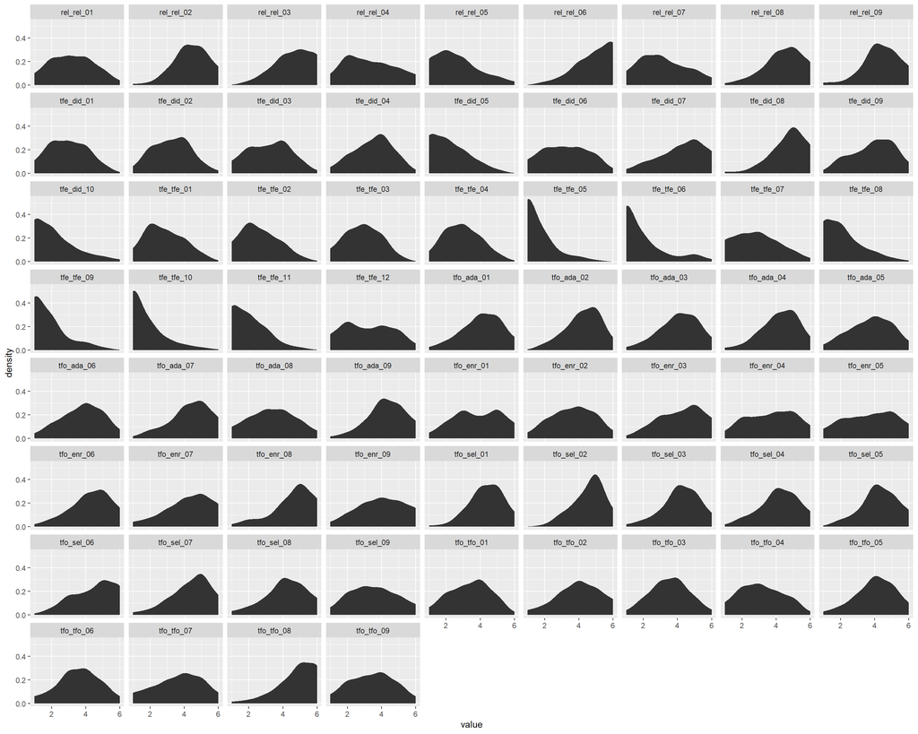

```r
efa_data_l <- gather(efa_data, key = "variable", value = "value", na.rm = T)

ggplot(efa_data_l, aes(x=value)) +
  facet_wrap(as.factor(efa_data_l$variable)) +
  stat_density(bw = 0.5)
```

# Results Study 1, FF1

## Number of factors

Comparing number of factors via fit indices

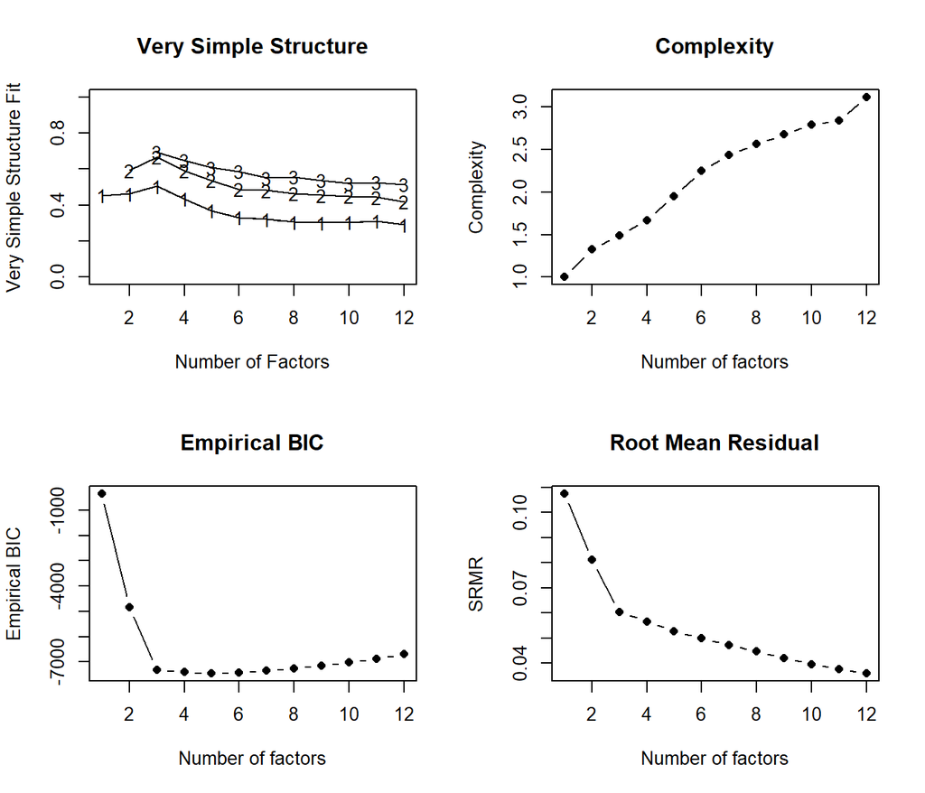

```
##
## Number of factors
## Call: vss(x = x, n = n, rotate = rotate, diagonal = diagonal, fm = fm,
##     n.obs = n.obs, plot = FALSE, title = title, use = use, cor = cor)
## VSS complexity 1 achieves a maximimum of 0.51  with  3  factors
## VSS complexity 2 achieves a maximimum of 0.67  with  3  factors
## The Velicer MAP achieves a minimum of 0.01  with  5  factors
## Empirical BIC achieves a minimum of  -7464  with  5  factors
## Sample Size adjusted BIC achieves a minimum of  -1712  with  6  factors
##
## Statistics by number of factors
##    vss1 vss2    map  dof chisq     prob sqresid  fit RMSEA   BIC SABIC complex
## 1  0.45 0.00 0.0154 2144  4191 4.6e-135     103 0.45 0.066 -7363  -569     1.0
## 2  0.46 0.59 0.0108 2078  3399  2.9e-67      77 0.59 0.054 -7799 -1214     1.3
## 3  0.51 0.67 0.0078 2013  2845  1.1e-31      58 0.69 0.043 -8003 -1624     1.5
## 4  0.43 0.59 0.0078 1949  2670  1.5e-25      62 0.67 0.041 -7833 -1657     1.7
## 5  0.37 0.54 0.0078 1886  2495  9.4e-20      64 0.66 0.038 -7669 -1692     2.0
## 6  0.33 0.49 0.0078 1824  2338  2.5e-15      64 0.66 0.036 -7492 -1712     2.2
## 7  0.32 0.48 0.0080 1763  2208  1.8e-12      62 0.67 0.034 -7293 -1706     2.4
## 8  0.31 0.47 0.0081 1703  2083  5.7e-10      61 0.67 0.032 -7095 -1698     2.6
## 9  0.30 0.46 0.0082 1644  1962  8.1e-08      61 0.68 0.029 -6898 -1688     2.7
## 10 0.31 0.45 0.0084 1586  1846  5.5e-06      61 0.68 0.027 -6701 -1675     2.8
## 11 0.31 0.44 0.0086 1529  1745  9.0e-05      60 0.68 0.025 -6495 -1650     2.8
## 12 0.29 0.42 0.0089 1473  1645  1.1e-03      60 0.68 0.023 -6293 -1625     3.1
##    eChisq  SRMR eCRMS  eBIC
## 1   11217 0.108 0.109  -337
## 2    6371 0.081 0.084 -4828
## 3    3536 0.060 0.063 -7312
## 4    3101 0.057 0.060 -7402
## 5    2700 0.053 0.057 -7464
## 6    2412 0.050 0.055 -7417
## 7    2164 0.047 0.053 -7337
## 8    1929 0.045 0.051 -7249
## 9    1706 0.042 0.049 -7154
## 10   1522 0.040 0.047 -7025
## 11   1373 0.038 0.045 -6867
## 12   1243 0.036 0.044 -6696
```

```r
library(psych)

corMat <- cor(efa_data, use = "pairwise.complete.obs")
nfactors(x = corMat, n.obs = 219, rotate = "oblimin", fm = "mle", n = 12)
```

**Inference**  
Indices point to solutions between 3 and 6 factors.  
We will have a deeper look into these four different solutions, their consistency within factors and possible content interpretation via EFAs.

## Exploratory factor analyses

### 3 factor solution

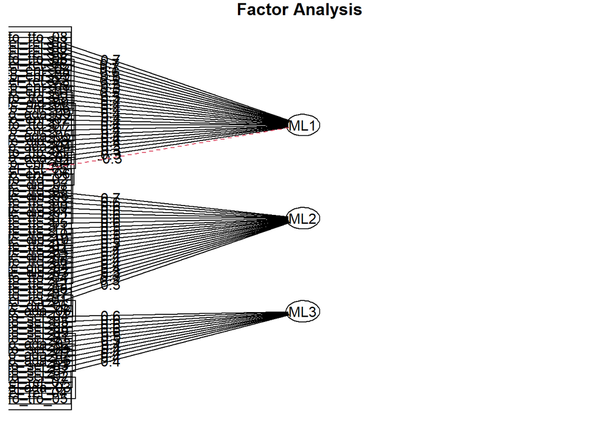

```r
# three factors with oblimin rotation and ML estimator
fa3  <- fa(r = corMat, nfactors = 3, n.obs = 219, rotate = "oblimin", fm = "ml")
fa.diagram(fa3)
```

**factors with ordered items ($\lambda$>.4) and item labels**

```r
# preparing item data.frame
rownames(items) <- items$Code

items <- items %>%
  dplyr::select(`Item Label`)

# sort items according to factor and loading
fa3_tab <- fa.lookup(f = fa3, dictionary = items, cut = .4)

kable(fa3_tab) %>%
  row_spec(13:27, background = "#c4fdff") %>%
  scroll_box(width = "100%")
```

|  | ML1 | ML2 | ML3 | h2 | com | Item Label |
| --- | --- | --- | --- | --- | --- | --- |
| tfo_tfo_08 | 0.69 | -0.04 | -0.06 | 0.47 | 1.02 | Professionelles Unterrichten ist das Ergebnis der Verbindung von wissenschaftlichem Wissen und erfahrungsbasierter Praxis. |
| rel_rel_03 | 0.68 | -0.04 | -0.08 | 0.45 | 1.04 | Wissenschaftliches Erklärungswissen und praktisches Handlungswissen haben unterschiedliche Funktionen, aber beide sind für professionelles Handeln bedeutsam. |
| rel_rel_09 | 0.67 | -0.03 | 0.02 | 0.45 | 1.01 | Lehrer*innen erlangen über ihren Unterricht neue Erkenntnis, wenn sie ihn vor dem Hintergrund wissenschaftlichen Wissens und ihren schulischen Erfahrungen nachvollziehen. |
| rel_rel_08 | 0.64 | -0.07 | -0.05 | 0.40 | 1.03 | Wenn ich meinen Unterricht sowohl aus einer wissenschaftlichen, als auch einer praktischen Sichtweise betrachte, verstehe ich vieles am Unterricht neu. |
| tfo_tfo_06 | 0.53 | 0.09 | -0.25 | 0.36 | 1.48 | Wissen über Schulalltag und Unterricht, kann erst dann als professionell bezeichnet werden, wenn es mit wissenschaftlichem Wissen ergänzt wurde. |
| rel_rel_06 | 0.52 | -0.06 | -0.01 | 0.26 | 1.03 | Wissenschaftliches Wissen und Erfahrungswissen sollten nicht gegeneinander ausgespielt werden, da sie beide wichtig sind. |
| tfo_enr_03 | 0.52 | 0.19 | 0.11 | 0.36 | 1.36 | Guter Unterricht basiert zu gleichen Teilen auf wissenschaftlichem Wissen und Erfahrungswissen aus der Praxis, auch wenn diese teilweise voneinander abweichen. |
| tfo_enr_09 | 0.50 | -0.04 | -0.04 | 0.24 | 1.03 | Die Frage, wie professionell unterrichtet wird, können Lehrer*innen und Wissenschaftler*innen nur gemeinsam beantworten. |
| rel_rel_02 | 0.49 | -0.18 | 0.20 | 0.30 | 1.64 | Betrachtet man Unterrichtssituationen aus einer praktischen und wissenschaftlichen Perspektive, dann führen deren Widersprüche und Gemeinsamkeiten zu einem neuen Verständnis der Situation. |
| tfo_enr_08 | 0.47 | 0.02 | -0.04 | 0.22 | 1.02 | Professionalität zeigt sich vor allem daran, dass man die eigene Praxis theoretisch reflektieren bzw. erforschen kann. |
| tfo_enr_01 | 0.43 | 0.28 | 0.07 | 0.31 | 1.78 | für den Unterricht sind Erkenntnisse aus Forschung und schulischer Erfahrung gleich wichtig, unabhängig davon, ob diese zusammenpassen oder nicht. |
| tfo_tfo_09 | 0.42 | 0.27 | -0.25 | 0.34 | 2.40 | Lehrer*innen sind nur dann professionell, wenn sie angeleitet wurden wissenschaftliches Wissen in ihre praktischen Erfahrungen zu integrieren. |
| tfe_tfe_08 | -0.10 | 0.68 | 0.06 | 0.45 | 1.06 | Schon allein die Kenntnis wissenschaftlichen Wissens ermöglicht es einer Person, Unterrichtssituationen professionell zu bewältigen. |
| tfe_did_05 | -0.04 | 0.63 | 0.03 | 0.39 | 1.01 | Wenn ihr das wissenschaftliche Wissen im Studium entsprechend unterrichtet wird, kann eine Lehrerin ohne Weiteres guten Unterricht halten. |
| tfe_tfe_03 | 0.06 | 0.63 | 0.02 | 0.42 | 1.02 | Wissenschaftliches Wissen wird durch Lehrer*innen unmittelbar auf praktisches Handeln in der Schule übertragen. |
| tfe_tfe_09 | -0.18 | 0.59 | -0.16 | 0.38 | 1.35 | Um Herausforderungen der Schulpraxis zu begegnen, genügt es über viel wissenschaftliches Wissen zu verfügen. |
| tfe_did_01 | 0.15 | 0.59 | -0.08 | 0.41 | 1.17 | Vorausgesetzt es wurde im Studium entsprechend vermittelt, leiten Lehrer*innen ihre Handlungsentscheidungen im Unterricht direkt aus wissenschaftlichem Wissen ab. |
| tfe_tfe_02 | 0.10 | 0.58 | -0.05 | 0.37 | 1.08 | Lehrer*innen wenden wissenschaftliches Wissen geradewegs im Schulalltag an. |
| tfe_tfe_05 | -0.20 | 0.57 | -0.05 | 0.33 | 1.24 | Um in der schulischen Praxis handeln zu können, benötigen Lehrer*innen allein wissenschaftliches Wissen. |
| tfe_tfe_11 | 0.01 | 0.53 | 0.09 | 0.29 | 1.06 | Wer eine wissenschaftliche Theorie kennt, weiß auch automatisch, unter welchen Bedingungen sie in der Praxis angewandt werden kann. |
| tfe_tfe_10 | -0.18 | 0.53 | -0.09 | 0.30 | 1.29 | Wer über genug wissenschaftliches Wissen verfügt, kommt mit jedem Praxisproblem zurecht. |
| tfe_did_10 | -0.12 | 0.52 | 0.07 | 0.27 | 1.14 | Um Lehramtsstudierende auf das professionelle Handeln in der Schulpraxis vorzubereiten, ist es ausreichend, ihnen das verfügbare wissenschaftliche Wissen und dessen Anwendungsbedingungen zu vermitteln… |
| tfe_tfe_01 | 0.19 | 0.50 | 0.03 | 0.32 | 1.29 | Lehrer*innen leiten aus wissenschaftlichem Wissen direkt Handlungsentscheidungen für den Unterricht ab. |
| tfe_tfe_04 | 0.23 | 0.48 | -0.01 | 0.32 | 1.43 | Lehrer*innen verwenden wissenschaftliches Wissen unmittelbar für ihre schulische Praxis. |
| tfe_did_02 | 0.24 | 0.42 | 0.05 | 0.27 | 1.61 | Wenn ihnen das Wissen entsprechend vermittelt wurde, übertragen Lehrer*innen wissenschaftliches Wissen unmittelbar auf ihr praktisches Handeln. |
| tfe_tfe_06 | 0.02 | 0.41 | -0.09 | 0.19 | 1.10 | Um guten Unterricht zu halten muss ein Lehrer nur auf wissenschaftliches Wissen zurückgreifen. |
| tfe_did_04 | 0.24 | 0.41 | 0.11 | 0.28 | 1.81 | Lehrer*innen verwenden wissenschaftliches Wissen unmittelbar für ihre schulische Praxis, gesetzt den Fall es wurde ihnen in geeigneter Form beigebracht. |
| tfo_sel_04 | -0.13 | 0.02 | 0.61 | 0.38 | 1.10 | Es ist Aufgabe der Lehrer*innen zu entscheiden, welche wissenschaftlichen Theorien für die Praxis tragfähig sind. |
| tfo_sel_05 | 0.05 | 0.09 | 0.59 | 0.36 | 1.06 | Lehrer*innen entscheiden auf Basis der eigenen Präferenzen, welche Erkenntnisse sie aus der Forschung für die eigene Praxis nutzbar machen. |
| tfo_sel_08 | -0.13 | -0.06 | 0.59 | 0.37 | 1.12 | Es ist Aufgabe der Lehrer*innen zu entscheiden, welche Relevanz wissenschaftliches Wissen für ihre Praxis hat. |
| tfo_sel_09 | -0.12 | 0.08 | 0.58 | 0.34 | 1.13 | Lehrer*innen dürfen sich aussuchen, welches wissenschaftliche Wissen sie für ihre Schulpraxis verwenden und welches nicht. |
| tfo_sel_01 | -0.03 | 0.02 | 0.58 | 0.33 | 1.01 | Lehrer*innen wählen selbst aus, welche Erkenntnisse sie aus der Forschung mit ihren Erfahrungen aus dem Unterricht verbinden. |
| tfo_ada_02 | 0.18 | -0.05 | 0.49 | 0.29 | 1.27 | Lehrer*innen passen wissenschaftliches Wissen aus der Perspektive ihrer praktischen Erfahrungen an. |
| tfo_sel_06 | -0.05 | -0.09 | 0.49 | 0.26 | 1.09 | Erst in der Praxis zeigt sich, ob wissenschaftliches Wissen auch nützlich ist. |
| tfo_ada_07 | 0.19 | -0.11 | 0.44 | 0.25 | 1.48 | Wie wissenschaftliches Wissen letztlich angewandt wird, kann durch die Lehrer*innen ausschließlich in der Praxis entschieden werden. |
| tfo_ada_06 | -0.12 | 0.04 | 0.42 | 0.18 | 1.18 | Lehrer*innen sollten wissenschaftliches Wissen daraufhin prüfen, welche Anteile des Wissens sie in ihrer eigenen Praxis gebrauchen können und den Rest in den Hintergrund stellen. |
| tfo_sel_03 | 0.37 | -0.03 | 0.41 | 0.32 | 1.99 | Lehrer*innen suchen sich aus den Theorieangeboten die für ihre Praxis passende Bausteine aus und setzen diese in ihr Erfahrungswissen ein. |

### 4 factor solution

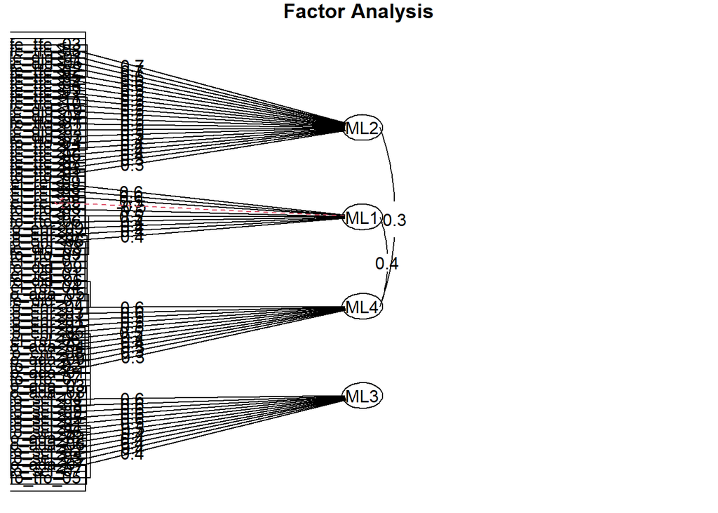

```r
# four factors with oblimin rotation and ML estimator
fa4  <- fa(r = corMat, nfactors = 4, n.obs = 219, rotate = "oblimin", fm = "ml")
fa.diagram(fa4)
```

**factors with ordered items ($\lambda$>.4) and item labels**

```r
# sort items according to factor and loading
fa4_tab <- fa.lookup(f = fa4, dictionary = items, cut = .4)

kable(fa4_tab) %>%
  row_spec(17:24, background = "#c4fdff") %>%
  row_spec(20, background = "#ff9a9a") %>%
  row_spec(33:39, background = "#c4fdff")
```

|  | ML2 | ML1 | ML4 | ML3 | h2 | com | Item Label |
| --- | --- | --- | --- | --- | --- | --- | --- |
| tfe_tfe_03 | 0.67 | 0.05 | -0.03 | 0.04 | 0.44 | 1.02 | Wissenschaftliches Wissen wird durch Lehrer*innen unmittelbar auf praktisches Handeln in der Schule übertragen. |
| tfe_tfe_08 | 0.65 | -0.17 | 0.04 | 0.05 | 0.45 | 1.15 | Schon allein die Kenntnis wissenschaftlichen Wissens ermöglicht es einer Person, Unterrichtssituationen professionell zu bewältigen. |
| tfe_did_01 | 0.63 | 0.14 | -0.02 | -0.06 | 0.43 | 1.12 | Vorausgesetzt es wurde im Studium entsprechend vermittelt, leiten Lehrer*innen ihre Handlungsentscheidungen im Unterricht direkt aus wissenschaftlichem Wissen ab. |
| tfe_did_05 | 0.63 | -0.08 | 0.01 | 0.03 | 0.39 | 1.04 | Wenn ihr das wissenschaftliche Wissen im Studium entsprechend unterrichtet wird, kann eine Lehrerin ohne Weiteres guten Unterricht halten. |
| tfe_tfe_02 | 0.59 | 0.04 | 0.04 | -0.06 | 0.37 | 1.04 | Lehrer*innen wenden wissenschaftliches Wissen geradewegs im Schulalltag an. |
| tfe_tfe_05 | 0.54 | -0.22 | -0.02 | -0.06 | 0.33 | 1.36 | Um in der schulischen Praxis handeln zu können, benötigen Lehrer*innen allein wissenschaftliches Wissen. |
| tfe_tfe_04 | 0.54 | 0.21 | 0.00 | 0.01 | 0.34 | 1.30 | Lehrer*innen verwenden wissenschaftliches Wissen unmittelbar für ihre schulische Praxis. |
| tfe_tfe_09 | 0.52 | -0.26 | 0.04 | -0.19 | 0.38 | 1.76 | Um Herausforderungen der Schulpraxis zu begegnen, genügt es über viel wissenschaftliches Wissen zu verfügen. |
| tfe_tfe_11 | 0.52 | -0.06 | 0.06 | 0.08 | 0.29 | 1.11 | Wer eine wissenschaftliche Theorie kennt, weiß auch automatisch, unter welchen Bedingungen sie in der Praxis angewandt werden kann. |
| tfe_tfe_10 | 0.50 | -0.20 | -0.02 | -0.10 | 0.29 | 1.42 | Wer über genug wissenschaftliches Wissen verfügt, kommt mit jedem Praxisproblem zurecht. |
| tfe_did_10 | 0.49 | -0.18 | 0.04 | 0.05 | 0.27 | 1.30 | Um Lehramtsstudierende auf das professionelle Handeln in der Schulpraxis vorzubereiten, ist es ausreichend, ihnen das verfügbare wissenschaftliche Wissen und dessen Anwendungsbedingungen zu vermitteln… |
| tfe_did_04 | 0.49 | 0.25 | -0.02 | 0.14 | 0.32 | 1.71 | Lehrer*innen verwenden wissenschaftliches Wissen unmittelbar für ihre schulische Praxis, gesetzt den Fall es wurde ihnen in geeigneter Form beigebracht. |
| tfe_tfe_01 | 0.49 | 0.05 | 0.16 | 0.01 | 0.32 | 1.25 | Lehrer*innen leiten aus wissenschaftlichem Wissen direkt Handlungsentscheidungen für den Unterricht ab. |
| tfe_did_02 | 0.47 | 0.20 | 0.04 | 0.06 | 0.29 | 1.40 | Wenn ihnen das Wissen entsprechend vermittelt wurde, übertragen Lehrer*innen wissenschaftliches Wissen unmittelbar auf ihr praktisches Handeln. |
| tfe_did_03 | 0.45 | 0.29 | -0.04 | 0.05 | 0.28 | 1.75 | Sofern das wissenschaftliche Wissen den Lehrer*innen angemessen gelehrt wurde, können sie daraus direkt Handlungsentscheidungen für den Unterricht ableiten. |
| tfo_tfo_04 | 0.41 | 0.24 | 0.07 | 0.11 | 0.27 | 1.85 | Lehrer*innen handeln professionell, weil Dozierende ihre Schulerfahrung in Aus- und Fortbildungen durch wissenschaftliches Wissen anreichern. |
| rel_rel_09 | 0.07 | 0.64 | 0.10 | 0.04 | 0.49 | 1.09 | Lehrer*innen erlangen über ihren Unterricht neue Erkenntnis, wenn sie ihn vor dem Hintergrund wissenschaftlichen Wissens und ihren schulischen Erfahrungen nachvollziehen. |
| rel_rel_08 | 0.02 | 0.59 | 0.13 | -0.02 | 0.42 | 1.10 | Wenn ich meinen Unterricht sowohl aus einer wissenschaftlichen, als auch einer praktischen Sichtweise betrachte, verstehe ich vieles am Unterricht neu. |
| rel_rel_03 | 0.01 | 0.54 | 0.23 | -0.08 | 0.45 | 1.41 | Wissenschaftliches Erklärungswissen und praktisches Handlungswissen haben unterschiedliche Funktionen, aber beide sind für professionelles Handeln bedeutsam. |
| rel_rel_05 | 0.16 | -0.52 | 0.23 | 0.11 | 0.27 | 1.70 | Wer eine enge Theorie-Praxis-Verknüpfung fordert, hat nicht verstanden, dass beide voneinander unabhängig und jeweils für sich genommen wertvoll sind. |
| tfo_tfo_08 | 0.00 | 0.51 | 0.29 | -0.07 | 0.46 | 1.61 | Professionelles Unterrichten ist das Ergebnis der Verbindung von wissenschaftlichem Wissen und erfahrungsbasierter Praxis. |
| rel_rel_02 | -0.10 | 0.47 | 0.08 | 0.23 | 0.32 | 1.60 | Betrachtet man Unterrichtssituationen aus einer praktischen und wissenschaftlichen Perspektive, dann führen deren Widersprüche und Gemeinsamkeiten zu einem neuen Verständnis der Situation. |
| tfo_tfo_06 | 0.14 | 0.43 | 0.15 | -0.24 | 0.35 | 2.15 | Wissen über Schulalltag und Unterricht, kann erst dann als professionell bezeichnet werden, wenn es mit wissenschaftlichem Wissen ergänzt wurde. |
| tfo_enr_09 | 0.01 | 0.42 | 0.14 | -0.04 | 0.25 | 1.25 | Die Frage, wie professionell unterrichtet wird, können Lehrer*innen und Wissenschaftler*innen nur gemeinsam beantworten. |
| tfo_enr_04 | -0.07 | -0.10 | 0.61 | 0.07 | 0.33 | 1.11 | Professionelle Schulpraxis heißt sich gleichmäßig auf praktisches und wissenschaftliches Wissen zu stützen, unabhängig davon, ob sich deren Aussagen unterscheiden oder nicht. |
| tfo_enr_03 | 0.07 | 0.11 | 0.60 | 0.01 | 0.46 | 1.09 | Guter Unterricht basiert zu gleichen Teilen auf wissenschaftlichem Wissen und Erfahrungswissen aus der Praxis, auch wenn diese teilweise voneinander abweichen. |
| tfo_enr_01 | 0.17 | 0.06 | 0.53 | -0.02 | 0.39 | 1.24 | für den Unterricht sind Erkenntnisse aus Forschung und schulischer Erfahrung gleich wichtig, unabhängig davon, ob diese zusammenpassen oder nicht. |
| tfo_enr_02 | 0.05 | 0.03 | 0.52 | -0.12 | 0.30 | 1.14 | Lehrer*innen müssen sich beim Unterrichten gleichwertig auf wissenschaftliche Forschung und praktische Erfahrung stützen, auch wenn diese nicht immer ohne weiteres zusammenpassen. |
| tfo_enr_05 | 0.19 | 0.05 | 0.48 | -0.13 | 0.36 | 1.52 | Wissenschaftliche Theorien und praktische Erfahrungen von Lehrer*innen sind gleich viel Wert, wenn es darum geht, Handlungen für die Schulpraxis abzuleiten. |
| rel_rel_06 | -0.14 | 0.21 | 0.47 | -0.08 | 0.32 | 1.62 | Wissenschaftliches Wissen und Erfahrungswissen sollten nicht gegeneinander ausgespielt werden, da sie beide wichtig sind. |
| tfo_ada_04 | -0.04 | 0.06 | 0.43 | 0.22 | 0.27 | 1.54 | Lehrer*innen entnehmen sich Bausteine aus wissenschaftlichem Wissen und gestalten diese für ihre Praxis um. |
| tfo_sel_04 | 0.04 | -0.07 | -0.06 | 0.62 | 0.39 | 1.05 | Es ist Aufgabe der Lehrer*innen zu entscheiden, welche wissenschaftlichen Theorien für die Praxis tragfähig sind. |
| tfo_sel_08 | -0.02 | -0.03 | -0.11 | 0.62 | 0.39 | 1.07 | Es ist Aufgabe der Lehrer*innen zu entscheiden, welche Relevanz wissenschaftliches Wissen für ihre Praxis hat. |
| tfo_sel_09 | 0.11 | -0.06 | -0.07 | 0.60 | 0.35 | 1.11 | Lehrer*innen dürfen sich aussuchen, welches wissenschaftliche Wissen sie für ihre Schulpraxis verwenden und welches nicht. |
| tfo_sel_05 | 0.05 | -0.07 | 0.19 | 0.56 | 0.36 | 1.29 | Lehrer*innen entscheiden auf Basis der eigenen Präferenzen, welche Erkenntnisse sie aus der Forschung für die eigene Praxis nutzbar machen. |
| tfo_sel_01 | 0.00 | -0.08 | 0.11 | 0.56 | 0.33 | 1.12 | Lehrer*innen wählen selbst aus, welche Erkenntnisse sie aus der Forschung mit ihren Erfahrungen aus dem Unterricht verbinden. |
| tfo_sel_06 | -0.02 | 0.08 | -0.15 | 0.53 | 0.30 | 1.20 | Erst in der Praxis zeigt sich, ob wissenschaftliches Wissen auch nützlich ist. |
| tfo_ada_02 | -0.06 | 0.06 | 0.20 | 0.46 | 0.29 | 1.45 | Lehrer*innen passen wissenschaftliches Wissen aus der Perspektive ihrer praktischen Erfahrungen an. |
| tfo_ada_06 | 0.08 | -0.02 | -0.13 | 0.45 | 0.20 | 1.25 | Lehrer*innen sollten wissenschaftliches Wissen daraufhin prüfen, welche Anteile des Wissens sie in ihrer eigenen Praxis gebrauchen können und den Rest in den Hintergrund stellen. |

### 5 factor solution

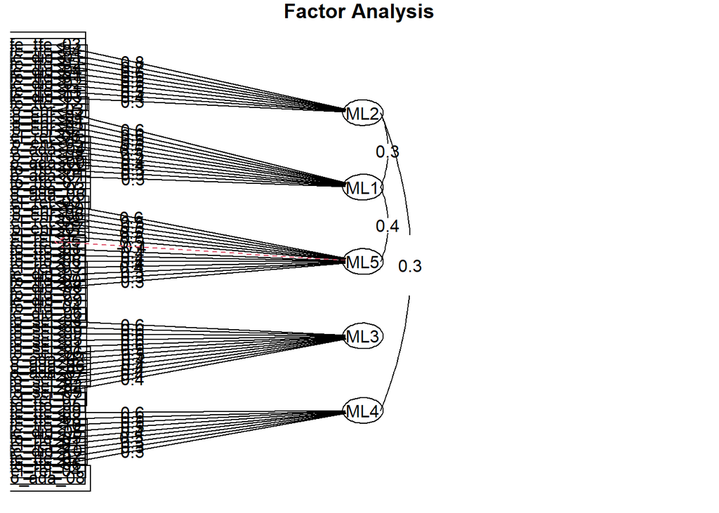

```r
# five factors with oblimin rotation and ML estimator
fa5  <- fa(r = corMat, nfactors = 5, n.obs = 219, rotate = "oblimin", fm = "ml")
fa.diagram(fa5)
```

**factors with ordered items ($\lambda$>.4) and item labels**

```r
# sort items according to factor and loading
fa5_tab <- fa.lookup(f = fa5, dictionary = items, cut = .4)

kable(fa5_tab) %>%
  row_spec(10:16, background = "#c4fdff") %>%
  row_spec(23, background = "#ff9a9a") %>%
  row_spec(24:30, background = "#c4fdff")
```

|  | ML2 | ML1 | ML5 | ML3 | ML4 | h2 | com | Item Label |
| --- | --- | --- | --- | --- | --- | --- | --- | --- |
| tfe_tfe_03 | 0.78 | -0.01 | -0.12 | 0.03 | 0.02 | 0.59 | 1.05 | Wissenschaftliches Wissen wird durch Lehrer*innen unmittelbar auf praktisches Handeln in der Schule übertragen. |
| tfe_tfe_04 | 0.67 | 0.01 | 0.06 | 0.00 | -0.05 | 0.45 | 1.03 | Lehrer*innen verwenden wissenschaftliches Wissen unmittelbar für ihre schulische Praxis. |
| tfe_did_01 | 0.60 | 0.00 | 0.06 | -0.07 | 0.13 | 0.46 | 1.14 | Vorausgesetzt es wurde im Studium entsprechend vermittelt, leiten Lehrer*innen ihre Handlungsentscheidungen im Unterricht direkt aus wissenschaftlichem Wissen ab. |
| tfe_tfe_02 | 0.55 | 0.07 | -0.03 | -0.07 | 0.14 | 0.41 | 1.21 | Lehrer*innen wenden wissenschaftliches Wissen geradewegs im Schulalltag an. |
| tfe_did_04 | 0.52 | -0.01 | 0.17 | 0.14 | 0.02 | 0.35 | 1.37 | Lehrer*innen verwenden wissenschaftliches Wissen unmittelbar für ihre schulische Praxis, gesetzt den Fall es wurde ihnen in geeigneter Form beigebracht. |
| tfe_tfe_01 | 0.48 | 0.18 | -0.02 | 0.00 | 0.09 | 0.36 | 1.35 | Lehrer*innen leiten aus wissenschaftlichem Wissen direkt Handlungsentscheidungen für den Unterricht ab. |
| tfe_did_02 | 0.45 | 0.06 | 0.14 | 0.06 | 0.08 | 0.30 | 1.35 | Wenn ihnen das Wissen entsprechend vermittelt wurde, übertragen Lehrer*innen wissenschaftliches Wissen unmittelbar auf ihr praktisches Handeln. |
| tfo_enr_03 | 0.13 | 0.63 | 0.02 | 0.01 | -0.04 | 0.48 | 1.09 | Guter Unterricht basiert zu gleichen Teilen auf wissenschaftlichem Wissen und Erfahrungswissen aus der Praxis, auch wenn diese teilweise voneinander abweichen. |
| tfo_enr_04 | -0.09 | 0.60 | -0.08 | 0.08 | 0.05 | 0.31 | 1.13 | Professionelle Schulpraxis heißt sich gleichmäßig auf praktisches und wissenschaftliches Wissen zu stützen, unabhängig davon, ob sich deren Aussagen unterscheiden oder nicht. |
| tfo_enr_01 | 0.06 | 0.54 | 0.09 | -0.02 | 0.16 | 0.40 | 1.27 | für den Unterricht sind Erkenntnisse aus Forschung und schulischer Erfahrung gleich wichtig, unabhängig davon, ob diese zusammenpassen oder nicht. |
| tfo_enr_02 | 0.03 | 0.51 | 0.03 | -0.12 | 0.05 | 0.30 | 1.14 | Lehrer*innen müssen sich beim Unterrichten gleichwertig auf wissenschaftliche Forschung und praktische Erfahrung stützen, auch wenn diese nicht immer ohne weiteres zusammenpassen. |
| rel_rel_06 | 0.07 | 0.49 | 0.07 | -0.09 | -0.25 | 0.34 | 1.65 | Wissenschaftliches Wissen und Erfahrungswissen sollten nicht gegeneinander ausgespielt werden, da sie beide wichtig sind. |
| tfo_enr_05 | 0.00 | 0.46 | 0.17 | -0.12 | 0.27 | 0.38 | 2.07 | Wissenschaftliche Theorien und praktische Erfahrungen von Lehrer*innen sind gleich viel Wert, wenn es darum geht, Handlungen für die Schulpraxis abzuleiten. |
| tfo_ada_04 | -0.02 | 0.44 | 0.04 | 0.22 | -0.02 | 0.27 | 1.48 | Lehrer*innen entnehmen sich Bausteine aus wissenschaftlichem Wissen und gestalten diese für ihre Praxis um. |
| rel_rel_09 | 0.15 | 0.14 | 0.56 | 0.03 | -0.15 | 0.48 | 1.45 | Lehrer*innen erlangen über ihren Unterricht neue Erkenntnis, wenn sie ihn vor dem Hintergrund wissenschaftlichen Wissens und ihren schulischen Erfahrungen nachvollziehen. |
| tfo_enr_09 | -0.12 | 0.12 | 0.54 | -0.03 | 0.09 | 0.34 | 1.28 | Die Frage, wie professionell unterrichtet wird, können Lehrer*innen und Wissenschaftler*innen nur gemeinsam beantworten. |
| tfo_enr_06 | -0.06 | -0.15 | 0.54 | 0.09 | 0.16 | 0.24 | 1.44 | Wissenschaftliche Forschung würde viel gewinnen, wenn Lehrer*innen bereits im Forschungsprozess eingebunden wären. |
| rel_rel_08 | 0.07 | 0.16 | 0.53 | -0.04 | -0.13 | 0.42 | 1.37 | Wenn ich meinen Unterricht sowohl aus einer wissenschaftlichen, als auch einer praktischen Sichtweise betrachte, verstehe ich vieles am Unterricht neu. |
| tfo_enr_07 | -0.08 | 0.00 | 0.50 | -0.04 | 0.10 | 0.24 | 1.15 | Um Herausforderungen und Fragen des Schulalltags zu lösen, müssen Lehrer*innen und wissenschaftlich Forschende zusammenarbeiten. |
| rel_rel_02 | -0.04 | 0.08 | 0.46 | 0.22 | -0.14 | 0.33 | 1.75 | Betrachtet man Unterrichtssituationen aus einer praktischen und wissenschaftlichen Perspektive, dann führen deren Widersprüche und Gemeinsamkeiten zu einem neuen Verständnis der Situation. |
| rel_rel_05 | -0.01 | 0.21 | -0.42 | 0.13 | 0.28 | 0.27 | 2.51 | Wer eine enge Theorie-Praxis-Verknüpfung fordert, hat nicht verstanden, dass beide voneinander unabhängig und jeweils für sich genommen wertvoll sind. |
| tfo_sel_04 | 0.07 | -0.04 | -0.10 | 0.62 | -0.04 | 0.39 | 1.09 | Es ist Aufgabe der Lehrer*innen zu entscheiden, welche wissenschaftlichen Theorien für die Praxis tragfähig sind. |
| tfo_sel_08 | 0.07 | -0.10 | -0.07 | 0.62 | -0.11 | 0.40 | 1.18 | Es ist Aufgabe der Lehrer*innen zu entscheiden, welche Relevanz wissenschaftliches Wissen für ihre Praxis hat. |
| tfo_sel_09 | 0.05 | -0.08 | 0.00 | 0.60 | 0.08 | 0.36 | 1.09 | Lehrer*innen dürfen sich aussuchen, welches wissenschaftliche Wissen sie für ihre Schulpraxis verwenden und welches nicht. |
| tfo_sel_05 | -0.02 | 0.17 | 0.01 | 0.56 | 0.10 | 0.37 | 1.27 | Lehrer*innen entscheiden auf Basis der eigenen Präferenzen, welche Erkenntnisse sie aus der Forschung für die eigene Praxis nutzbar machen. |
| tfo_sel_01 | -0.04 | 0.09 | -0.02 | 0.56 | 0.06 | 0.33 | 1.08 | Lehrer*innen wählen selbst aus, welche Erkenntnisse sie aus der Forschung mit ihren Erfahrungen aus dem Unterricht verbinden. |
| tfo_sel_06 | -0.02 | -0.15 | 0.11 | 0.53 | -0.03 | 0.30 | 1.26 | Erst in der Praxis zeigt sich, ob wissenschaftliches Wissen auch nützlich ist. |
| tfo_ada_02 | 0.10 | 0.23 | -0.06 | 0.46 | -0.20 | 0.32 | 2.06 | Lehrer*innen passen wissenschaftliches Wissen aus der Perspektive ihrer praktischen Erfahrungen an. |
| tfo_ada_06 | 0.03 | -0.12 | 0.01 | 0.45 | 0.05 | 0.20 | 1.19 | Lehrer*innen sollten wissenschaftliches Wissen daraufhin prüfen, welche Anteile des Wissens sie in ihrer eigenen Praxis gebrauchen können und den Rest in den Hintergrund stellen. |
| tfo_ada_07 | -0.19 | 0.23 | 0.11 | 0.41 | 0.02 | 0.27 | 2.24 | Wie wissenschaftliches Wissen letztlich angewandt wird, kann durch die Lehrer*innen ausschließlich in der Praxis entschieden werden. |
| tfe_tfe_09 | 0.12 | 0.02 | -0.05 | -0.18 | 0.58 | 0.45 | 1.29 | Um Herausforderungen der Schulpraxis zu begegnen, genügt es über viel wissenschaftliches Wissen zu verfügen. |
| tfe_tfe_08 | 0.30 | 0.04 | -0.03 | 0.05 | 0.51 | 0.47 | 1.68 | Schon allein die Kenntnis wissenschaftlichen Wissens ermöglicht es einer Person, Unterrichtssituationen professionell zu bewältigen. |
| tfe_tfe_10 | 0.15 | -0.04 | -0.02 | -0.09 | 0.50 | 0.34 | 1.27 | Wer über genug wissenschaftliches Wissen verfügt, kommt mit jedem Praxisproblem zurecht. |
| tfe_did_05 | 0.30 | 0.00 | 0.07 | 0.04 | 0.48 | 0.42 | 1.73 | Wenn ihr das wissenschaftliche Wissen im Studium entsprechend unterrichtet wird, kann eine Lehrerin ohne Weiteres guten Unterricht halten. |
| tfe_tfe_05 | 0.25 | -0.03 | -0.10 | -0.05 | 0.43 | 0.34 | 1.77 | Um in der schulischen Praxis handeln zu können, benötigen Lehrer*innen allein wissenschaftliches Wissen. |

### 6 factor solution

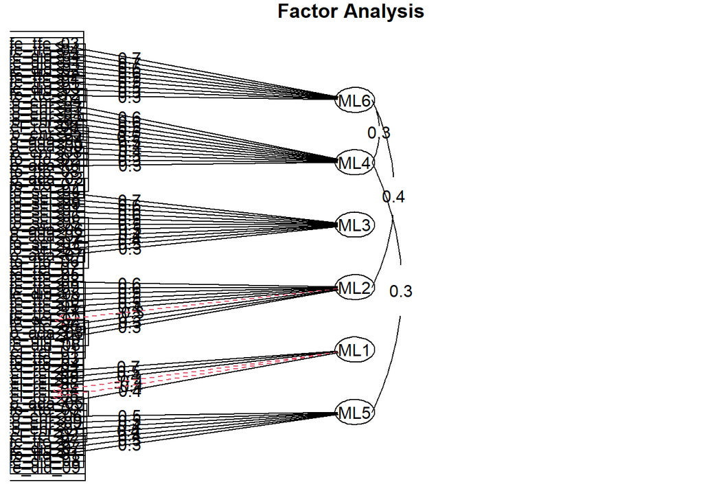

```r
# six factors with oblimin rotation and ML estimator
fa6  <- fa(r = corMat, nfactors = 6, n.obs = 219, rotate = "oblimin", fm = "ml")
fa.diagram(fa6)
```

**factors with ordered items ($\lambda$>.4) and item labels**

```r
# sort items according to factor and loading
fa6_tab <- fa.lookup(f = fa6, dictionary = items, cut = .4)

kable(fa6_tab) %>%
  row_spec(9:15, background = "#c4fdff") %>%
  row_spec(23:27, background = "#c4fdff") %>%
  row_spec(33:35, background = "#c4fdff") %>%
  row_spec(36, background = "#ff9a9a") %>%
  scroll_box(width = "100%")
```

|  | ML6 | ML4 | ML3 | ML2 | ML1 | ML5 | h2 | com | Item Label |
| --- | --- | --- | --- | --- | --- | --- | --- | --- | --- |
| tfe_tfe_03 | 0.74 | -0.03 | 0.04 | 0.11 | 0.04 | -0.17 | 0.59 | 1.16 | Wissenschaftliches Wissen wird durch Lehrer*innen unmittelbar auf praktisches Handeln in der Schule übertragen. |
| tfe_tfe_04 | 0.70 | 0.01 | -0.03 | -0.05 | 0.01 | 0.01 | 0.48 | 1.02 | Lehrer*innen verwenden wissenschaftliches Wissen unmittelbar für ihre schulische Praxis. |
| tfe_did_04 | 0.63 | 0.02 | 0.06 | -0.08 | -0.11 | 0.20 | 0.44 | 1.33 | Lehrer*innen verwenden wissenschaftliches Wissen unmittelbar für ihre schulische Praxis, gesetzt den Fall es wurde ihnen in geeigneter Form beigebracht. |
| tfe_did_01 | 0.59 | -0.01 | -0.08 | 0.16 | 0.04 | 0.01 | 0.46 | 1.20 | Vorausgesetzt es wurde im Studium entsprechend vermittelt, leiten Lehrer*innen ihre Handlungsentscheidungen im Unterricht direkt aus wissenschaftlichem Wissen ab. |
| tfe_did_02 | 0.50 | 0.08 | 0.01 | 0.04 | -0.05 | 0.14 | 0.34 | 1.26 | Wenn ihnen das Wissen entsprechend vermittelt wurde, übertragen Lehrer*innen wissenschaftliches Wissen unmittelbar auf ihr praktisches Handeln. |
| tfe_tfe_02 | 0.48 | 0.03 | -0.04 | 0.25 | 0.11 | -0.09 | 0.41 | 1.74 | Lehrer*innen wenden wissenschaftliches Wissen geradewegs im Schulalltag an. |
| tfe_tfe_01 | 0.46 | 0.16 | 0.00 | 0.14 | 0.07 | -0.07 | 0.36 | 1.57 | Lehrer*innen leiten aus wissenschaftlichem Wissen direkt Handlungsentscheidungen für den Unterricht ab. |
| tfo_enr_04 | -0.02 | 0.62 | 0.02 | -0.03 | -0.10 | -0.02 | 0.34 | 1.07 | Professionelle Schulpraxis heißt sich gleichmäßig auf praktisches und wissenschaftliches Wissen zu stützen, unabhängig davon, ob sich deren Aussagen unterscheiden oder nicht. |
| tfo_enr_03 | 0.09 | 0.57 | 0.02 | 0.05 | 0.23 | -0.08 | 0.48 | 1.42 | Guter Unterricht basiert zu gleichen Teilen auf wissenschaftlichem Wissen und Erfahrungswissen aus der Praxis, auch wenn diese teilweise voneinander abweichen. |
| tfo_enr_01 | 0.01 | 0.49 | 0.00 | 0.24 | 0.18 | 0.02 | 0.41 | 1.75 | für den Unterricht sind Erkenntnisse aus Forschung und schulischer Erfahrung gleich wichtig, unabhängig davon, ob diese zusammenpassen oder nicht. |
| tfo_enr_02 | 0.05 | 0.49 | -0.14 | 0.05 | 0.08 | 0.00 | 0.30 | 1.25 | Lehrer*innen müssen sich beim Unterrichten gleichwertig auf wissenschaftliche Forschung und praktische Erfahrung stützen, auch wenn diese nicht immer ohne weiteres zusammenpassen. |
| rel_rel_06 | 0.15 | 0.48 | -0.13 | -0.29 | 0.08 | 0.01 | 0.38 | 2.16 | Wissenschaftliches Wissen und Erfahrungswissen sollten nicht gegeneinander ausgespielt werden, da sie beide wichtig sind. |
| tfo_enr_05 | 0.02 | 0.46 | -0.15 | 0.24 | 0.02 | 0.17 | 0.39 | 2.09 | Wissenschaftliche Theorien und praktische Erfahrungen von Lehrer*innen sind gleich viel Wert, wenn es darum geht, Handlungen für die Schulpraxis abzuleiten. |
| tfo_ada_04 | 0.00 | 0.44 | 0.19 | -0.04 | 0.05 | 0.03 | 0.27 | 1.43 | Lehrer*innen entnehmen sich Bausteine aus wissenschaftlichem Wissen und gestalten diese für ihre Praxis um. |
| tfo_sel_04 | -0.05 | -0.08 | 0.71 | 0.10 | 0.19 | -0.16 | 0.53 | 1.32 | Es ist Aufgabe der Lehrer*innen zu entscheiden, welche wissenschaftlichen Theorien für die Praxis tragfähig sind. |
| tfo_sel_08 | 0.07 | -0.08 | 0.61 | -0.12 | -0.04 | -0.05 | 0.40 | 1.16 | Es ist Aufgabe der Lehrer*innen zu entscheiden, welche Relevanz wissenschaftliches Wissen für ihre Praxis hat. |
| tfo_sel_09 | 0.04 | -0.04 | 0.58 | 0.05 | -0.11 | 0.07 | 0.35 | 1.14 | Lehrer*innen dürfen sich aussuchen, welches wissenschaftliche Wissen sie für ihre Schulpraxis verwenden und welches nicht. |
| tfo_sel_01 | -0.05 | 0.11 | 0.55 | 0.05 | -0.05 | 0.03 | 0.33 | 1.14 | Lehrer*innen wählen selbst aus, welche Erkenntnisse sie aus der Forschung mit ihren Erfahrungen aus dem Unterricht verbinden. |
| tfo_sel_06 | -0.02 | -0.13 | 0.53 | -0.05 | 0.01 | 0.12 | 0.30 | 1.25 | Erst in der Praxis zeigt sich, ob wissenschaftliches Wissen auch nützlich ist. |
| tfo_sel_05 | 0.04 | 0.23 | 0.50 | 0.00 | -0.19 | 0.12 | 0.38 | 1.90 | Lehrer*innen entscheiden auf Basis der eigenen Präferenzen, welche Erkenntnisse sie aus der Forschung für die eigene Praxis nutzbar machen. |
| tfo_ada_06 | 0.00 | -0.11 | 0.45 | 0.07 | -0.01 | 0.04 | 0.21 | 1.18 | Lehrer*innen sollten wissenschaftliches Wissen daraufhin prüfen, welche Anteile des Wissens sie in ihrer eigenen Praxis gebrauchen können und den Rest in den Hintergrund stellen. |
| tfo_ada_02 | 0.11 | 0.23 | 0.44 | -0.20 | 0.02 | -0.05 | 0.32 | 2.21 | Lehrer*innen passen wissenschaftliches Wissen aus der Perspektive ihrer praktischen Erfahrungen an. |
| tfe_tfe_08 | 0.17 | 0.01 | 0.11 | 0.64 | 0.07 | -0.03 | 0.53 | 1.23 | Schon allein die Kenntnis wissenschaftlichen Wissens ermöglicht es einer Person, Unterrichtssituationen professionell zu bewältigen. |
| tfe_tfe_09 | 0.07 | 0.03 | -0.17 | 0.59 | -0.14 | 0.03 | 0.45 | 1.34 | Um Herausforderungen der Schulpraxis zu begegnen, genügt es über viel wissenschaftliches Wissen zu verfügen. |
| tfe_did_05 | 0.24 | 0.01 | 0.04 | 0.51 | -0.05 | 0.10 | 0.42 | 1.53 | Wenn ihr das wissenschaftliche Wissen im Studium entsprechend unterrichtet wird, kann eine Lehrerin ohne Weiteres guten Unterricht halten. |
| tfe_tfe_10 | 0.11 | -0.03 | -0.09 | 0.50 | -0.14 | 0.06 | 0.33 | 1.36 | Wer über genug wissenschaftliches Wissen verfügt, kommt mit jedem Praxisproblem zurecht. |
| tfe_tfe_05 | 0.19 | -0.03 | -0.03 | 0.47 | -0.11 | -0.04 | 0.34 | 1.46 | Um in der schulischen Praxis handeln zu können, benötigen Lehrer*innen allein wissenschaftliches Wissen. |
| rel_rel_03 | 0.03 | 0.16 | -0.01 | -0.01 | 0.73 | 0.04 | 0.67 | 1.10 | Wissenschaftliches Erklärungswissen und praktisches Handlungswissen haben unterschiedliche Funktionen, aber beide sind für professionelles Handeln bedeutsam. |
| rel_rel_09 | 0.11 | 0.08 | 0.04 | -0.07 | 0.46 | 0.34 | 0.50 | 2.13 | Lehrer*innen erlangen über ihren Unterricht neue Erkenntnis, wenn sie ihn vor dem Hintergrund wissenschaftlichen Wissens und ihren schulischen Erfahrungen nachvollziehen. |
| rel_rel_08 | 0.04 | 0.11 | -0.03 | -0.05 | 0.43 | 0.33 | 0.43 | 2.10 | Wenn ich meinen Unterricht sowohl aus einer wissenschaftlichen, als auch einer praktischen Sichtweise betrachte, verstehe ich vieles am Unterricht neu. |
| rel_rel_04 | -0.04 | 0.24 | 0.04 | 0.11 | -0.41 | 0.14 | 0.20 | 2.11 | Wenn man versucht eine Theorie-Praxis-Integration zu erzwingen, verliert man die Vorteile beider Seiten. |
| tfo_enr_06 | -0.01 | -0.11 | 0.05 | 0.07 | 0.07 | 0.51 | 0.25 | 1.20 | Wissenschaftliche Forschung würde viel gewinnen, wenn Lehrer*innen bereits im Forschungsprozess eingebunden wären. |
| tfo_enr_09 | -0.07 | 0.14 | -0.08 | 0.02 | 0.16 | 0.47 | 0.33 | 1.53 | Die Frage, wie professionell unterrichtet wird, können Lehrer*innen und Wissenschaftler*innen nur gemeinsam beantworten. |
| tfo_enr_07 | -0.06 | 0.01 | -0.06 | 0.07 | 0.17 | 0.42 | 0.23 | 1.48 | Um Herausforderungen und Fragen des Schulalltags zu lösen, müssen Lehrer*innen und wissenschaftlich Forschende zusammenarbeiten. |
| rel_rel_02 | 0.05 | 0.11 | 0.16 | -0.24 | 0.10 | 0.42 | 0.36 | 2.33 | Betrachtet man Unterrichtssituationen aus einer praktischen und wissenschaftlichen Perspektive, dann führen deren Widersprüche und Gemeinsamkeiten zu einem neuen Verständnis der Situation. |
| tfe_tfe_07 | 0.23 | -0.03 | -0.06 | 0.16 | -0.31 | 0.41 | 0.32 | 2.95 | Wer über Kenntnisse von wissenschaftlichem Wissen verfügt, kann auch professionell unterrichten. |

# Reliability Analysis

Fit indices between the different factor solutions are quite similar. However, when consulting the items with highest loadings, the four factor solution

- allows clear interpretation of the factors itself (homogenity within factors)
- allows clear distinction of interpretation between factors (heterogenity between factors)

**4 Factor, McDonalds $\omega$**

```r
# subsetting data for reliability analysis
rel_data4.1 <- efa_data %>%
  dplyr::select("tfe_tfe_03", "tfe_tfe_08", "tfe_did_01", "tfe_did_05", "tfe_tfe_02")    # 5 items with highest weights from transfer factor

rel_data4.2 <- efa_data %>%
  dplyr::select("tfo_sel_01", "tfo_sel_04", "tfo_sel_05", "tfo_sel_08", "tfo_sel_09")    # 5 items with highest weights from selection factor

rel_data4.3 <- efa_data %>%
  dplyr::select("tfo_enr_01", "tfo_enr_02", "tfo_enr_03", "tfo_enr_04", "tfo_enr_05")    # 5 items with highest weights from enrichment factor

rel_data4.4 <- efa_data %>%
  dplyr::select("rel_rel_02", "rel_rel_03", "rel_rel_08", "rel_rel_09")                  # 4 items with highest weights from relationierung factor
                                                                                  # (with one negative and one transformation item deleted)
```

- **McDonalds** $\sf{\omega_{Transfer}}$= 0.762, **95%CI**[NA, NA]
- **McDonalds** $\sf{\omega_{Selektion}}$= 0.737, **95%CI**[NA, NA]
- **McDonalds** $\sf{\omega_{Enrichment}}$= 0.747, **95%CI**[NA, NA]
- **McDonalds** $\sf{\omega_{Relationierung}}$= 0.756, **95%CI**[NA, NA]

# Reformulation of several items

Several items of the instrument will be reformulated due to possible two-dimensionality (that can be further avoided): E.g. the item “Wissenschaftliches Wissen wird durch Lehrer*innen unmittelbar auf praktisches Handeln in der Schule übertragen.” asks (1) if there is a **possibility** of transfer and (2) if teachers **actually** perform transformations (an empirical question). We decided to lose the empirical side of the question as we are interested in the perceived possibilities.

In column “itemlabel_re”, deleted words are marked by strikethrough, newly added words are italicised.  
New item labels can be found in the column “itemlabel”.

```r
items_4f <- read.csv("https://raw.githubusercontent.com/j-5chneider/uzvvtp-las/master/data/items_4f.csv", sep = ";")

kable(items_4f) %>%
  row_spec(6:10, background = "#c4fdff") %>%
  row_spec(16:19, background = "#c4fdff") %>%
  collapse_rows(columns = 1, valign = "middle") %>%
  scroll_box(width = "100%")
```

| Skala | Code_old | Code | itemlabel_re | itemlabel |
| --- | --- | --- | --- | --- |
| Transfer | tfe_tfe_02 | tfe_1 | Lehrer*innen *können* wenden wissenschaftliches Wissen geradewegs im Schulalltag an *wenden*. | Lehrer*innen können wissenschaftliches Wissen geradewegs im Schulalltag anwenden. |
|  | tfe_tfe_03 | tfe_2 | Wissenschaftliches Wissen *kann* wird durch Lehrer*innen unmittelbar auf praktisches Handeln in der Schule übertragen *werden*. | Wissenschaftliches Wissen kann durch Lehrer*innen unmittelbar auf praktisches Handeln in der Schule übertragen werden. |
|  | tfe_tfe_08 | tfe_3 | Schon allein die Kenntnis wissenschaftlichen Wissens ermöglicht es einer Person, Unterrichtssituationen professionell zu bewältigen. | Schon allein die Kenntnis wissenschaftlichen Wissens ermöglicht es einer Person, Unterrichtssituationen professionell zu bewältigen. |
|  | tfe_did_01 | tfe_4 | Vorausgesetzt es wurde im Studium entsprechend vermittelt, *können* leiten Lehrer*innen ihre Handlungsentscheidungen im Unterricht direkt aus wissenschaftlichem Wissen ab *leiten*. | Vorausgesetzt es wurde im Studium entsprechend vermittelt, können Lehrer*innen ihre Handlungsentscheidungen im Unterricht direkt aus wissenschaftlichem Wissen ableiten. |
|  | tfe_did_05 | tfe_5 | Wenn ihr das wissenschaftliche Wissen im Studium entsprechend unterrichtet wird, kann eine Lehrerin ohne Weiteres guten Unterricht halten. | Wenn ihr das wissenschaftliche Wissen im Studium entsprechend unterrichtet wird, kann eine Lehrerin ohne Weiteres guten Unterricht halten. |
| Selektion | tfo_sel_01 | sel_1 | Lehrer*innen *dürfen* wählen selbst auswählen, welche Erkenntnisse sie aus der Forschung mit ihren Erfahrungen aus dem Unterricht verbinden. | Lehrer*innen dürfen selbst auswählen, welche Erkenntnisse sie aus der Forschung mit ihren Erfahrungen aus dem Unterricht verbinden. |
|  | tfo_sel_02 | sel_2 | Ob Lehrer*innen eine wissenschaftliche Theorie mit ihren Praxiserfahrungen verbinden, hängt davon ab, wie relevant sie diese Theorie für ihre Praxis einschätzen. | Ob Lehrer*innen eine wissenschaftliche Theorie mit ihren Praxiserfahrungen verbinden, hängt davon ab, wie relevant sie diese Theorie für ihre Praxis einschätzen. |
|  | tfo_sel_04 | sel_3 | Es ist Aufgabe der Lehrer*innen zu entscheiden, welche wissenschaftlichen Theorien für die Praxis tragfähig sind. | Es ist Aufgabe der Lehrer*innen zu entscheiden, welche wissenschaftlichen Theorien für die Praxis tragfähig sind. |
|  | tfo_sel_08 | sel_4 | Es ist Aufgabe der Lehrer*innen zu entscheiden, welche Relevanz wissenschaftliches Wissen für ihre Praxis hat. | Es ist Aufgabe der Lehrer*innen zu entscheiden, welche Relevanz wissenschaftliches Wissen für ihre Praxis hat. |
|  | tfo_sel_09 | sel_5 | Lehrer*innen dürfen sich aussuchen, welches wissenschaftliche Wissen sie für ihre Schulpraxis verwenden und welches nicht. | Lehrer*innen dürfen sich aussuchen, welches wissenschaftliche Wissen sie für ihre Schulpraxis verwenden und welches nicht. |
| Enrichment | tfo_enr_01 | enr_1 | für den Unterricht sind Erkenntnisse aus Forschung und schulischer Erfahrung gleich wichtig, unabhängig davon, ob diese zusammenpassen oder nicht. | für den Unterricht sind Erkenntnisse aus Forschung und schulischer Erfahrung gleich wichtig, unabhängig davon, ob diese zusammenpassen oder nicht. |
|  | tfo_enr_02 | enr_2 | Lehrer*innen müssen sich beim Unterrichten gleichwertig auf wissenschaftliche Forschung und praktische Erfahrung stützen, auch wenn diese nicht immer ohne weiteres zusammenpassen. | Lehrer*innen müssen sich beim Unterrichten gleichwertig auf wissenschaftliche Forschung und praktische Erfahrung stützen, auch wenn diese nicht immer ohne weiteres zusammenpassen. |
|  | tfo_enr_03 | enr_3 | Guter Unterricht basiert zu gleichen Teilen auf wissenschaftlichem Wissen und Erfahrungswissen aus der Praxis, auch wenn diese teilweise voneinander abweichen. | Guter Unterricht basiert zu gleichen Teilen auf wissenschaftlichem Wissen und Erfahrungswissen aus der Praxis, auch wenn diese teilweise voneinander abweichen. |
|  | tfo_enr_04 | enr_4 | Professionelle Schulpraxis heißt sich gleichmäßig auf praktisches und wissenschaftliches Wissen zu stützen, unabhängig davon, ob sich deren Aussagen unterscheiden oder nicht. | Professionelle Schulpraxis heißt, sich gleichmäßig auf praktisches und wissenschaftliches Wissen zu stützen, unabhängig davon, ob sich deren Aussagen unterscheiden oder nicht. |
|  | tfo_enr_05 | enr_5 | Wissenschaftliche Theorien und praktische Erfahrungen von Lehrer*innen sind gleich viel Wert, wenn es darum geht, Handlungen für die Schulpraxis abzuleiten. | Wissenschaftliche Theorien und praktische Erfahrungen von Lehrer*innen sind gleich viel Wert, wenn es darum geht, Handlungen für die Schulpraxis abzuleiten. |
| Relationierung | rel_rel_02 | rel_1 | Betrachtet man Unterrichtssituationen aus einer praktischen und wissenschaftlichen Perspektive, dann führen deren Widersprüche und Gemeinsamkeiten zu einem neuen Verständnis der Situation. | Betrachtet man Unterrichtssituationen aus einer praktischen und wissenschaftlichen Perspektive, dann führen deren Widersprüche und Gemeinsamkeiten zu einem neuen Verständnis der Situation. |
|  | rel_rel_03 | rel_2 | Wissenschaftliches Erklärungswissen und praktisches Handlungswissen haben unterschiedliche Funktionen, aber beide sind für professionelles Handeln bedeutsam. | Wissenschaftliches Erklärungswissen und praktisches Handlungswissen haben unterschiedliche Funktionen, aber beide sind für professionelles Handeln bedeutsam. |
|  | rel_rel_08 | rel_3 | Wenn ich meinen Unterricht sowohl aus einer wissenschaftlichen, als auch einer praktischen Sichtweise betrachte, verstehe ich vieles am Unterricht neu. | Wenn ich meinen Unterricht sowohl aus einer wissenschaftlichen, als auch einer praktischen Sichtweise betrachte, verstehe ich vieles am Unterricht neu. |
|  | rel_rel_09 | rel_4 | Lehrer*innen erlangen über ihren Unterricht neue Erkenntnis, wenn sie ihn vor dem Hintergrund wissenschaftlichen Wissens und ihren schulischen Erfahrungen nachvollziehen. | Lehrer*innen erlangen über ihren Unterricht neue Erkenntnis, wenn sie ihn vor dem Hintergrund wissenschaftlichen Wissens und ihrer schulischen Erfahrungen nachvollziehen. |

# Used packages & Setup

```r
installed.packages()[names(sessionInfo()$otherPkgs), "Version"]
```

```
##        psych      fBasics   kableExtra        knitr          rio    lubridate
##      "2.4.1"    "4032.96" "1.3.4.9000"       "1.45"      "1.0.1"      "1.9.3"
##      forcats      stringr        dplyr        purrr        readr        tidyr
##      "1.0.0"      "1.5.1"      "1.1.4"      "1.0.2"      "2.1.5"      "1.3.1"
##       tibble      ggplot2    tidyverse
##      "3.2.1"      "3.4.4"      "2.0.0"
```

```r
R.Version()
```

```
## $platform
## [1] "x86_64-w64-mingw32"
##
## $arch
## [1] "x86_64"
##
## $os
## [1] "mingw32"
##
## $crt
## [1] "ucrt"
##
## $system
## [1] "x86_64, mingw32"
##
## $status
## [1] ""
##
## $major
## [1] "4"
##
## $minor
## [1] "3.1"
##
## $year
## [1] "2023"
##
## $month
## [1] "06"
##
## $day
## [1] "16"
##
## $`svn rev`
## [1] "84548"
##
## $language
## [1] "R"
##
## $version.string
## [1] "R version 4.3.1 (2023-06-16 ucrt)"
##
## $nickname
## [1] "Beagle Scouts"
```